# HW4

```python
%matplotlib inline
import numpy as np
import matplotlib
import matplotlib.pyplot as plt
import scipy
from scipy import stats
```

Problem 0

```python
t = np.linspace(0,np.pi*100,int(1e5))
N = 10+np.sin(t)
bkgd = stats.norm.rvs(size=int(1e5))*np.sqrt(N)+N
```

Problem 1: Subsets of Data

Making a scatter plot of the first 1000 data points. The forms of x and y axis are given above as t and N, we just have to do some array slicing.

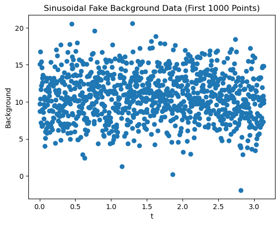

```python
fig,ax = plt.subplots(1,1)
x = t[0:1000]
y = bkgd[0:1000]
plt.scatter(x,y)
plt.title('Sinusoidal Fake Background Data (First 1000 Points)')
plt.ylabel('Background')
plt.xlabel('t')
plt.show()
```

Now, let's generalize this code to any range of data given.

```python
def gen_scat(start,end):
    fig, ax = plt.subplots(1,1)
    gen_t = t[start:end]
    gen_bkgd = bkgd[start:end]
    plt.scatter(gen_t,gen_bkgd)
    plt.title('Sinusoidal Background Data: Points ' + str(start) + ' to ' + str(end))
    plt.ylabel('Background')
    plt.xlabel('t')
```

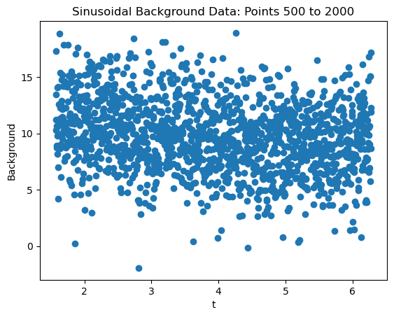

```python
gen_scat(500,2000)
```

This is generalized code to give any range of data and plots it. Let's produce a plot of data somewhere in the middle of the array:

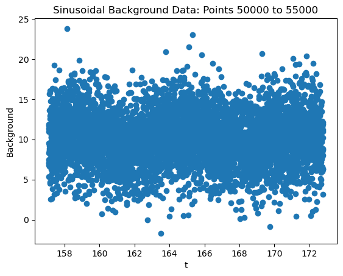

```python
gen_scat(50000,55000)
```

This just looks like a blob though, so let's reduce the amount of data being plotted

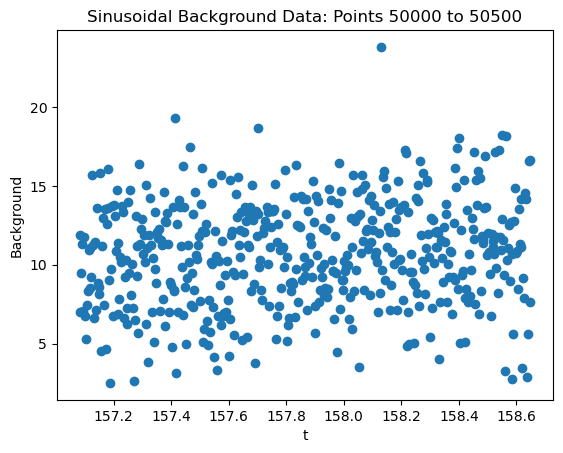

```python
gen_scat(50000,50500)
```

Now, in order to generalize this code further to include the step in the data, I will introduce an extra input into the function gen_scat and let's plot the whole range of data:

```python
def gen_scat(start,end,step):
    fig, ax = plt.subplots(1,1)
    gen_t = t[start:end:step]
    gen_bkgd = bkgd[start:end:step]
    plt.scatter(gen_t,gen_bkgd)
    plt.title('Sinusoidal Background Data: Points ' + str(start) + ' to ' + str(end) + ' With Step of ' + str(step))
    plt.xlabel('t')
    plt.ylabel('Background')
```

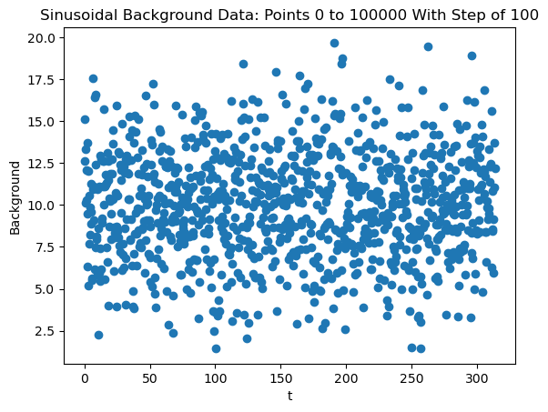

```python
gen_scat(0,100000,100)
```

This is further generalized to include the step which means that we can pick our certain points in a defined range of data.

Problem 2: Density

Sometimes, seeing discrete data points is not the most helpful in analyzing data. We might want to see the density of our data so that we can see where most of the data points are and where there is a lack of data entry. This can be done with a histogram as shown below.

```python
t = np.linspace(0,np.pi*100,int(1e5))
N = 10+np.sin(t)
bkgd = stats.norm.rvs(size=int(1e5))*np.sqrt(N)+N
```

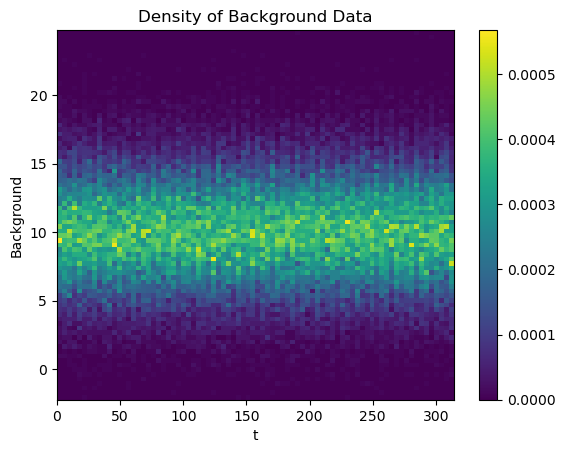

```python
fig,ax = plt.subplots(1,1)
dist = plt.hist2d(t,bkgd,density=True,bins=80)
plt.colorbar()
plt.title('Density of Background Data')
plt.xlabel('t')
plt.ylabel('Background')
plt.show()
```

The density option in hist2d is set to true so that we can see the probability density which is more helpful in this case because it tells us where the data is most likely to be. The colorbar shows which area is most likely to be dense in data points.

B. Each color represents the density. This is a 2d color plot which means the changing colors represent another dimension. In this case the yellow is the most dense areas and the dark blue/violet are the less dense areas. But there is another aspect to this. As I said above, this plot really shows the probability density. What this means is that the yellow color shown is where the data points are most likely to lie and the dark purple is where the data points are least likely to be. This is helpful because we are able to make predictions on where future data points would lie. The color bar assigns numbers to the colors and we can see that yellow has the highest probability density and purple has the least.

Problem 3: Folding

```python
t = np.linspace(0,np.pi*100,int(1e5))
N = 10+np.sin(t)
bkgd = stats.norm.rvs(size=int(1e5))*np.sqrt(N)+N
```

```python
foldedt = np.mod(t,2*np.pi)
```

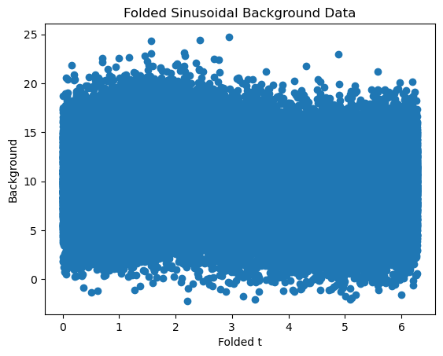

```python
plt.scatter(foldedt,bkgd)
plt.title('Folded Sinusoidal Background Data')
plt.xlabel('Folded t')
plt.ylabel('Background')
plt.show()
```

We can start to see the sinusoidal wave of the data. Notice how the left side of the data is a little higher than the right side giving that sinusoidal wave look. This should make sense because the data set we were given is also sinusoidal. All that was done was folding of the data to bring out the sinusoidal shape.

B. Let's use a 2D histogram to see if that helps with the shape of the graph.

[figure not shown]

```python
plt.hist2d(foldedt,bkgd,bins=80)
plt.title('Plot Showing the Density of Folded Data')
plt.xlabel('Folded t')
plt.ylabel('Background')
plt.show()
```

From this, it is obvious to spot the sinusoidal wave.